# Desafio: Usando matrizes RGB (imagens) no Numpy

Toda imagem colorida, para o computador, nada mais é do que um conjunto de três matrizes (vermelha, verde e azul (RGB de red, green e blue)), onde cada uma dessas matriz traz a intensidade da respectiva cor para cada um dos pixels.

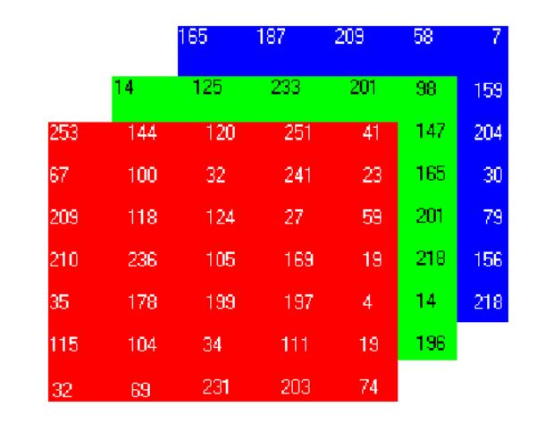

Os valores vão de 0 a 255, onde 0 representa a ausência dessa cor e 255 a intensidade mais forte. Se tivermos um píxel puramente vermelho ele será representado pelos seguintes valores em cada matriz:

- R = 255
- G = 0
- B = 0

Na imagem acima, cada célula da matriz representa um píxel. Uma imagem é formada por vários pixels.

Já uma imagem preta e branca ou também chamada de escala de cinza apresenta apenas uma matriz com valores entre 0 e 255 ou entre 0 e 1, onde quanto mais perto de 0, mais escuro é o píxel e quanto mais distante, mais claro.

[figure not shown]

## Desafio

Para esse desafio, nós iremos abrir uma imagem, inspecionar ela para ver como é representada no computador, e efetuar algumas operações como:

- Transformar em preto e branco
- Cortar a imagem no meio (tanto na vertical, quanto na horizontal)
- Apagar o nariz do nosso cachorro

Para fazer o desafio será necessário executar no terminal um dos seguintes comandos:

```
pip install scikit-image matplotlib
```

ou

```
conda install scikit-image matplotlib
```

## Carregando a imagem e visualizando

```python
from skimage import io
import numpy as np
import matplotlib.pyplot as plt

%matplotlib inline
```

```python
img = io.imread('shiba-p.jpg') # Carregamento da imagem

print(type(img))

plt.imshow(img) # Exibição da imagem
```

[output not shown]

```
<class 'numpy.ndarray'>
```

```python
img.shape
```

```
(640, 640, 3)
```

```python
img_copia = img.copy() #creating a copy of the original image in order not to mess with original.
plt.imshow(img_copia)
```

[output not shown]

## 1. Cortando no meio vertical

```python
vertical_slice = img_copia[:,320:] #slicing vertically a copy of the original image editing shape
```

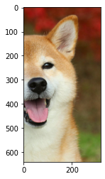

```python
plt.imshow(vertical_slice)
```

## 2. Cortando no meio horizontal

```python
horizontal_slice = img_copia[320:, :,:] #slicing horizontally a copy of the original image editing shape
```

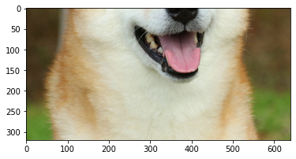

```python
plt.imshow(horizontal_slice)
```

## 3. Apagando o nariz

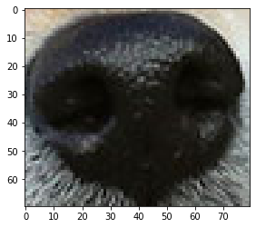

```python
finding_nose = img_copia[290:360, 340:420,:]
plt.imshow(finding_nose)
```

🇬🇧 Assignment for students of the Data Science Degree module IV - Programming Techniques I at Let's Code.

🧑🏻‍🏫 Professor: [Pedro Gengo](https://github.com/pedrogengo)

Just as an observation, the professor placed us in groups of 4 in order to discuss this assignment.

Therefore, up to this part in which one was supposed to find the correct postion of the nose in order to sucessfully replace it with a colour block, the solutions were discovered and performed together.

**Peers of this assignment were**:

- 👨🏻‍🎓 Daniel Gianfranco Watanabe
- 👨🏻‍🎓 Fernando Alves da Silva
- 👩🏻‍🎓 Karina Ferreira de Amorim
- 👩🏻‍🎓 Maeba Tomaselli

🇧🇷 Exercício para os alunos do curso Degree de Data Science módulo IV - Técnicas de Programação I da Let's Code.

🧑🏻‍🏫 Professor: Pedro Gengo

Como observação, o professor nos colocou em grupos de 4 pessoas para discutirmos o exercício.

Por isso, até a parte em que era preciso encontrar a posição do nariz para então substituí-lo por um bloco de cor, as soluções foram descobertas e executadas em conjunto.

**Colegas participantes do grupo para o exercício**:

- 👨🏻‍🎓 Daniel Gianfranco Watanabe
- 👨🏻‍🎓 Fernando Alves da Silva
- 👩🏻‍🎓 Karina Ferreira de Amorim
- 👩🏻‍🎓 Maeba Tomaselli

```python
delete_nose = img.copy() #creating another copy of the original image in order to delete the nose
                        #this will prevent us from ruining the original and the first copy.
plt.imshow(delete_nose)
```

[output not shown]

```python
delete_nose[290:360 , 340:428 , [0,1,2]] = 255
```

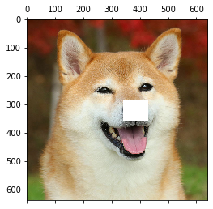

```python
plt.matshow(delete_nose)
```

## 4. Transformando para escala de cinza

A fórmula para transforma para escala de cinza é:

$$0.299 * \text{red} + 0.587 * \text{green} + 0.114 * \text{blue}$$

E para exibir a matriz gerada use:

```
plt.imshow(nome_da_sua_matriz, cmap="gray")
```

Obs: Lembre-se que para a escala de cinza o resultado deve ser apenas uma matriz, ou seja, o shape será (640, 640)

🇬🇧 This solution was brought by the colleague **Willian de Oliveira**, who used *np.arrays* and had a different insight for slicing. In this scenario, the outside layer/landscape when having the value "1" attributed to it, presents a slightly darker shade of gray and it's possible to change this value to have a lighter or darker shade.

🇧🇷 A solução abaixo foi compartilhada pelo colega **Willian de Oliveira**, que utilizou *np.arrays* em seu trabalho e trouxe uma visão diferente para a parte de divisão/slicing. Neste cenário, a camada externa/paisagem ao ter o valor "1" atribuído apresenta um cinza um pouco mais escuro e é possível alterar este valor para transformar em tons de cinza mais claros ou mais escuros.

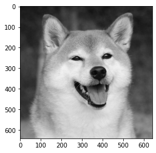

```python
plt.imshow(img[:,:,1], cmap="gray")
```

```python
# This solution was developed by myself using the information provided by the professor
# and implementing it in a new matrix.
```

```python
img_colour_change = img.copy() #creates a new copy of the original so we can properly change its colour
```

```python
#creating a matrix to again edit the shape assigning the colours according to the professor's note/hint.

gray_img = img_colour_change[:,:,0]* 0.299 + img_colour_change[:,:,1]* 0.587 + img_colour_change[:,:,2]* 0.114
```

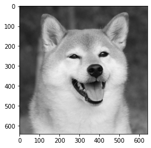

```python
plt.imshow(gray_img, cmap='gray')
```